# National Cosmetology Written Practical Examination CIB

Effective: January 01, 2022

[figure not shown]

## CANDIDATE INFORMATION BULLETIN (CIB)

**EXAMINATION CONTENT AND IMPORTANT INSTRUCTIONS**

*Please visit your official examination provider website OR www.nictesting.org for the most current bulletin prior to testing.*

The National Cosmetology Written Practical Examination is a licensure examination for Cosmetology, developed by the National-Interstate Council of State Boards of Cosmetology (NIC).

This bulletin contains IMPORTANT INFORMATION regarding National Cosmetology Written Practical Examination content and administration for core services and additional sections and references.

The time allowed for this examination is 120 minutes.

*PLEASE REVIEW ALL INFORMATION CAREFULLY.*

For each NIC National Written Practical Examination, there are multiple parts to every Candidate Information Bulletin (CIB):

- **Important Instructions and Examination Content Domain Sections** – This provides information and guidelines related to administration of the Written Practical examination and information about the scope of content covered in the Written Practical examination.
- **References** – This provides a list of references used to develop and support the content covered in NIC examinations. References will be the same across exam types for each exam.

*BE CERTAIN TO REVIEW ALL PARTS OF THIS NIC EXAMINATION CIB CAREFULLY!*

## IMPORTANT INSTRUCTIONS

### General

- Do not leave the examination area without permission. Permission must be obtained to leave the examination area for any reason, including restroom usage or at the completion of the examination. *Picture ID is required for re-entry into the examination.*
- All examinations are administered in a testing environment.

### Standardized Administration

Due to standardization of the NIC National Examinations, proctors and examiners are required to adhere to the following standards:

- With the exception of verbal instructions, proctors and examination administration personnel are NOT allowed to speak with candidates.
- If a candidate experiences an emergency situation, they may notify the proctor by raising their hand.

#### Prohibited Items

- The following provides examples of materials and actions that are prohibited in the examination room during the examination administration:
  - Possession of cellular phones, watches (of any kind), pagers, tablets, computers, projectors, cameras, or any other electronic or recording devices, printed materials, or handwritten notes.
  - Purses, bags, coats, hats, and any other personal items not directly needed to complete the examination, are not allowed.
- Communicating to other candidates or any examiner.
- Exhibiting disruptive behavior. The above referenced items or actions are not an exhaustive list.

Failure to comply with any of these conditions or exhibiting ANY behavior that suggests an effort to cheat will result in immediate dismissal from the examination and the candidates’ actions reported to the proper authorities.

## COSMETOLOGY WRITTEN PRACTICAL EXAMINATION CONTENT OUTLINE

### Domain Details

The following outlines the scope of content covered by the NIC National Cosmetology Written Practical Examination. The percentages represent the percentage of items from each domain. The examination contains 75 items, of which 65 items are weighted and contribute to the candidate’s final score.

1. Scientific Concepts (20%)
   1. Infection Control and Safety Practices
      1. Recognize purpose and/or effects of infection control principles
         1. Process of infection control: Recognize when cross-contamination occurs
         2. Process of infection control: Prevention of cross-contamination
         3. Process of infection control: Differentiate between the purpose of single- and multi-use tools
      2. Apply blood contact procedures
   2. Basic Chemistry of Products Used in Cosmetology
      1. Recognize purpose and effects of products and ingredients
      2. Recognize physical interactions with chemicals
      3. Recognize chemical reactions (e.g., overexposure, chemical burn)
2. Hair Care and Services (45%)
   1. Client Consultation, Analysis and Documentation for Hair Care Services
      1. Evaluate condition of client’s hair and scalp (i.e., assessment)
      2. Recognize conditions that would prohibit service (i.e., contraindications)
      3. Determine services or products
      4. Recognize purpose and interpret results of preliminary tests (e.g., predisposition and strand tests)
      5. Establish/Maintain client records (e.g., service history, client card, medical history)
   2. Tools used in Hair Care Services
      1. Identify function, purpose and infection control procedures of tools used in hair services:
         1. Equipment (e.g., chair, workstation)
         2. Implements (e.g., razors, shears, combs/brushes)
         3. Supplies and materials (e.g., towels, drape, neck strips)
         4. Electrical tools (e.g., irons, blow dryers, clippers)
         5. Proper disinfection procedures
      2. Recognize safe practices for use of tools (i.e., equipment, implements, supplies, ergonomics)
   3. Hair Care
      1. Apply knowledge of principles and procedures for shampooing and conditioning
      2. Apply knowledge of principles and procedures for scalp treatments and scalp massage
      3. Apply knowledge of draping (e.g., chemical, shampoo, cutting)
   4. Hair Design
      1. Apply knowledge of principles, procedures and safety of hair cutting and shaping
      2. Apply knowledge of principles, procedures and safety of hair styling:
         1. Wet styling
         2. Thermal styling
         3. Natural hair styling (e.g., braiding)
      3. Apply knowledge of principles, procedures and safety of hair enhancements
      4. Apply principles of balance and design (e.g., facial shape, physical structure)
   5. Chemical Services
      1. Apply knowledge of principles, procedures and safety for:
         1. Hair coloring (including corrective color)
         2. Hair lightening
         3. Foiling
         4. Chemical hair relaxing/restructuring and curl reduction: Hydroxide
         5. Chemical hair relaxing/restructuring and curl reduction: Thio
         6. Chemical hair relaxing/restructuring and curl reduction: Keratin
         7. Chemical waving/texturizing: Alkaline
         8. Chemical waving/texturizing: Acid
            1. Chemical waving/texturizing: Non-thio
         9. Chemical waving/texturizing: Keratin
3. Skin Care and Services (15%)
   1. Client Consultation, analysis and Documentation for Skin Care Services
      1. Evaluate condition of client’s skin:
         1. Skin type
         2. Skin condition
      2. Identify contraindications:
         1. Disorders
         2. Diseases
      3. Determine services and products
      4. Establish/Maintain client records (e.g., service history, client card, medical history)
   2. Tools used for skin care services
      1. Identify function, purpose and infection control procedures of tools:
         1. Equipment (e.g., chair, steamer)
         2. Implements (e.g., tweezers, brushes, extractors)
         3. Supplies, products, and materials (e.g., creams, masks, towels, body and hair drapes)
         4. Proper disinfection procedures
      2. Recognize and understand safe practices for use of tools (i.e., equipment, implements, supplies, ergonomics)
   3. Facial skin care services
      1. Apply knowledge of principles, procedures and safety for:
         1. Cleansing
         2. Steaming
         3. Exfoliation
         4. Extraction
         5. Massage
         6. Masks
         7. Hair Removal: Tweezing
         8. Hair Removal: Depilatory
            1. Hair Removal: Hard wax
         9. Hair Removal: Soft wax
         10. Makeup application
         11. Electrical equipment
4. Nail Care and Services (20%)
   1. Client Consultation, Analysis and Documentation for nail care services
      1. Evaluate condition of client’s nails
      2. Identify contraindications:
         1. Disorders
         2. Diseases
      3. Determine services and products
      4. Establish/Maintain client records (e.g., service history, client card, medical history)
   2. Tools used in nail care services
      1. Identify function, purpose and infection control procedures of tools:
         1. Equipment (e.g., workstation, pedicure basin)
         2. Implements (e.g., nippers, file)
         3. Supplies, products, and materials (e.g., towels, creams, polish)
         4. Proper disinfection procedures
      2. Recognize and understand safe practices for use of tools (i.e., equipment, implements, supplies, ergonomics)
   3. Apply knowledge of principles, procedures and safety for basic manicure and pedicure
   4. Apply knowledge of principles, procedures and safety for application, maintenance, and removal of nail enhancements:
      1. Nail tips
      2. Acrylics

## NATIONAL COSMETOLOGY WRITTEN PRACTICAL EXAMINATION SAMPLE QUESTIONS

1. The FIRST step prior to disinfecting implements is to

   A. rinse thoroughly with hot water

   B. remove all hair and visible debris.

   C. completely immerse in a sanitizing solution.

   D. expose to UV light for 15 minutes.

2. The application of facial makeup will become unsafe when which of the following occurs?

   A. Product is transferred to a pallet

   B. Fingers are used to transfer product to a pallet

   C. Hand is used to brace during application

   D. Fingers are used for product application

3. During the client consultation for a manicure, the practitioner determines the client has brittle nails. Which of the following treatments is recommended for this condition?

   A. Apply a clear top coat

   B. Perform a paraffin treatment

   C. Conditioning oil manicure

   D. Buff with 3-way buffer

Answer Key

| Item | Key |
| --- | --- |
| 1 | B |
| 2 | B |
| 3 | C |
| 4 | A, C |
| 5 | B |

4. Please select all images of multi-use items.

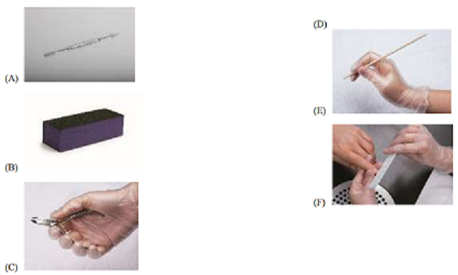

5. Select the finger hole on the image below.

[figure not shown]

## NATIONAL-INTERSTATE COUNCIL OF STATE BOARDS OF COSMETOLOGY (NIC) REFERENCES

This list provides the references used to develop and support the content covered in the NIC National Cosmetology examinations. References will be the same across exam types for each exam. Candidates are responsible for using these most updated versions of references, as these editions were used to reference test material.

Standard

*Pivot Point Fundamentals: Cosmetology, (101 – 113)*

Copyrighted ©2016 Pivot Point International, Inc.

1st Edition, 1st Printing, November 2016

978–1-940593-56-2

Pivot Point International, Inc. www.pivot-point.com

info@pivot-point.com; 847-886-0500, Ext. 7399

*Milady Standard Cosmetology + Foundations*

Copyrighted 2023

14th Edition

9780357871492

Milady www.Milady.com

Info@Milady.com;

*Cosmetology Career Concepts*

Copyrighted 2014

CLIC International

*Today’s Class: Cosmetology 1, Cosmetology, 2, Basic Esthetics 1 & 2, Nail Technician*

Copyrighted 2016

Melior, Inc.

877-224-0435

Supplemental

*Milady Standard Cosmetology*

Copyrighted 2016

13th Edition

9781285769417

Milady www.Milady.com

Info@Milady.com;

*Salon Fundamentals Cosmetology*

Copyrighted 2014

3rd Edition

Pivot Point International, Inc. www.pivot-point.com

info@pivot-point.com; 847-886-0500, Ext. 7399

Copyright 2022 National-Interstate Council of State Boards of Cosmetology, Inc.